# Part 0. Ready to start

#### Fig. 4G: Schematic representation of the hypothetical frequency dynamics of HBmem clonal lineage.

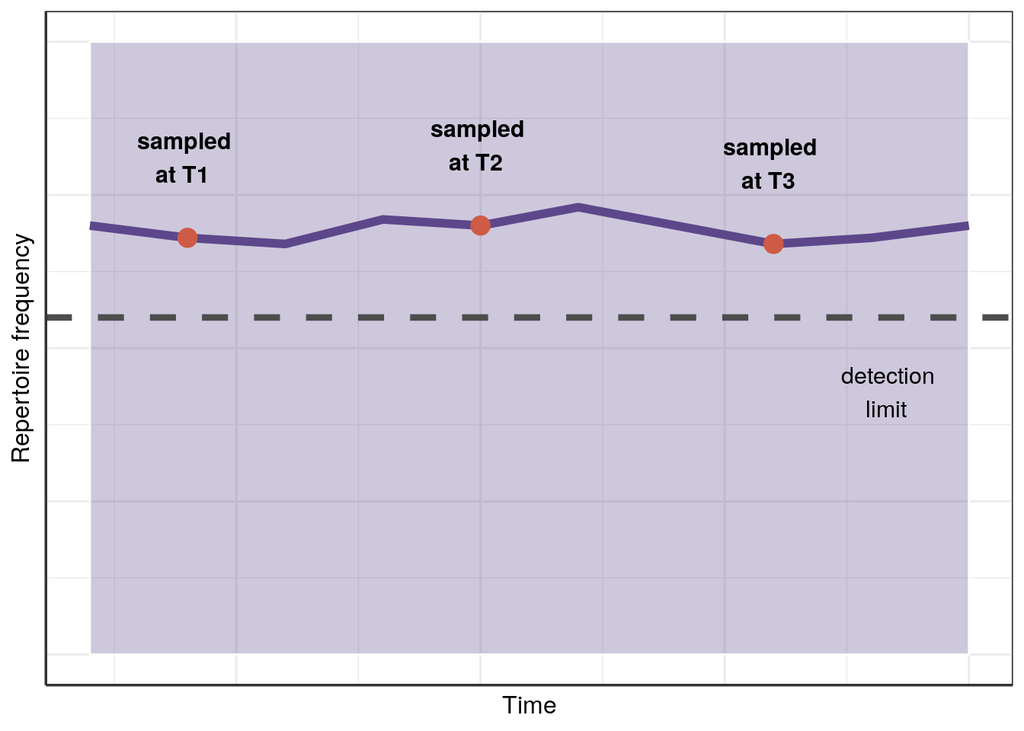

```r
df <- cbind(1:10, c(0.007, 0.0068, 0.0067, 0.0071, 0.007, 0.0073, 0.007, 0.0067, 0.0068, 0.007),
            c(0.002, 0.0019, 0.002, 0.002, 0.008, 0.005, 0.0025, 0.002, 0.002, 0.002),
            c(0.0058, 0.0061, 0.0057, 0.0058, 0.0076, 0.006, 0.0058, 0.006, 0.0058, 0.0056))
df <- data.frame(df)
colnames(df) <- c("x1", "y1", "y2", "y3")

p_scheme1 <- ggplot(df) +
  annotate("rect", ymin=0, ymax=0.01, xmin = 1, xmax = 10,
           alpha=0.3, fill = "mediumpurple4", color="white") +
  geom_line(aes(x = x1, y = y1), color = "mediumpurple4", size = 2) +
  geom_hline(yintercept = 0.0055, linetype="dashed", color = "grey30", size = 1.5) +
  annotate("text", x = 9.2, y=0.004, label = 'plain("detection \n    limit")', parse = TRUE, size = 4) +
  annotate("point", x = df$x1[2], y = df$y1[2], colour = "coral3", size = 4) +
  annotate("point", x = df$x1[5], y = df$y1[5], colour = "coral3", size = 4) +
  annotate("point", x = df$x1[8], y = df$y1[8], colour = "coral3", size = 4) +
  annotate("text", x = df$x1[2], y = df$y1[2] + 0.001, label = 'bold("sampled \n   at T1")', parse = TRUE, size = 4) +
  annotate("text", x = df$x1[5], y = df$y1[5] + 0.001, label = 'bold("sampled \n   at T2")', parse = TRUE, size = 4) +
  annotate("text", x = df$x1[8], y = df$y1[8] + 0.001, label = 'bold("sampled \n   at T3")', parse = TRUE, size = 4) +
  scale_y_continuous("Repertoire frequency", limits = c(0, 0.01)) +
  scale_x_continuous("Time") +
  #ggtitle("    Sampling of HBmem group") +
  my_theme +
  theme(axis.ticks.x=element_blank(),
        axis.ticks.y=element_blank(),
        axis.text.x=element_blank(),
        axis.text.y=element_blank())

p_scheme1
```

#### Fig. 4H: Schematic representation of the hypothetical frequency dynamics of LBmem clonal lineage.

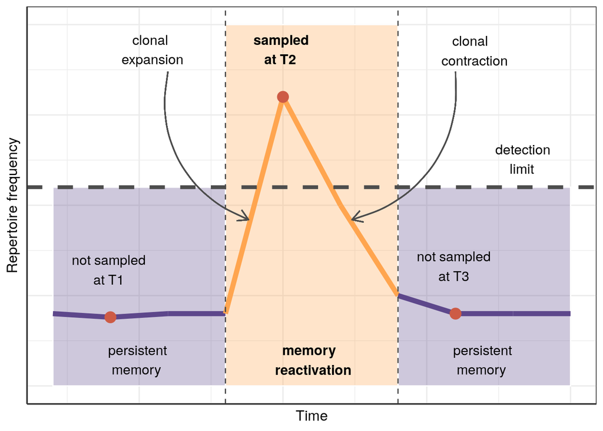

```r
p_scheme2 <- ggplot(df) +
  annotate("rect", ymin=0, ymax=0.0055, xmin = 1, xmax = df$x1[4],
           alpha=0.3, fill = "mediumpurple4", color="white") +
  annotate("rect", ymin=0, ymax=0.0055, xmin = df$x1[7], xmax = 10,
           alpha=0.3, fill = "mediumpurple4", color="white") +
  annotate("rect", ymin=0, ymax=0.01, xmin = df$x1[4], xmax = df$x1[7],
           alpha=0.3, fill = "tan1", color="white") +
  geom_line(aes(x = x1, y = y2, colour=(x1 > 3 & x1 < 7), group = 1),  size = 2) +
  geom_hline(yintercept = 0.0055, linetype="dashed", color = "grey30", size = 1.5) +
  geom_vline(xintercept = df$x1[4], linetype="dashed", color = "grey30") +
  geom_vline(xintercept = df$x1[7], linetype="dashed", color = "grey30") +
  annotate("text", x = 9.2, y=0.006, label = 'plain("detection \n    limit")', parse = TRUE, size = 4) +
  annotate("point", x = df$x1[2], y = df$y2[2], colour = "coral3", size = 4) +
  annotate("point", x = df$x1[5], y = df$y2[5], colour = "coral3", size = 4) +
  annotate("point", x = df$x1[8], y = df$y2[8], colour = "coral3", size = 4) +
  annotate("text", x = df$x1[2], y = df$y2[2] + 0.001, label = 'plain("not sampled \n      at T1")', parse = TRUE, size = 4) +
  annotate("text", x = df$x1[5], y = df$y2[5] + 0.001, label = 'bold("sampled \n   at T2")', parse = TRUE, size =4) +
  annotate("text", x = df$x1[8], y = df$y2[8] + 0.001, label = 'plain("not sampled \n      at T3")', parse = TRUE, size = 4) +
  annotate("text", x = 2.5, y = 0.0004, label = 'plain("persistent \n memory")', parse = TRUE, size = 4) +
  annotate("text", x = 5.5, y = 0.0004, label = 'bold("   memory \n reactivation")', parse = TRUE, size = 4) +
  annotate("text", x = 8.5, y = 0.0004, label = 'plain("persistent \n memory")', parse = TRUE, size = 4) +
  annotate("text", x = 2.7, y = 0.009, label = 'plain("    clonal \n expansion")', parse = TRUE, size = 4) +
  annotate("text", x = 8.3, y = 0.009, label = 'plain("    clonal \n contraction")', parse = TRUE, size = 4) +
  geom_curve(x = 3, y = 0.0087, xend = 4.4, yend = 0.0046, curvature = 0.4, color = "grey30",
             arrow = arrow(length = unit(0.03, "npc"))) +
  geom_curve(x = 8, y = 0.0087, xend = 6.2, yend = 0.0046, curvature = -0.4, color = "grey30",
             arrow = arrow(length = unit(0.03, "npc"))) +
  scale_colour_manual(values = c("mediumpurple4", "tan1")) +
  scale_y_continuous("Repertoire frequency", limits = c(0, 0.01)) +
  scale_x_continuous("Time") +
  #ggtitle("    Sampling of LBmem group") +
  my_theme +
  theme(axis.ticks.x=element_blank(),
        axis.ticks.y=element_blank(),
        axis.text.x=element_blank(),
        axis.text.y=element_blank())

p_scheme2
```

#### Fig. 4E: Schematic representation of the hypothetical frequency dynamics of clonal lineage with HBmem - LBmem transition, shown of Fig. 4F.

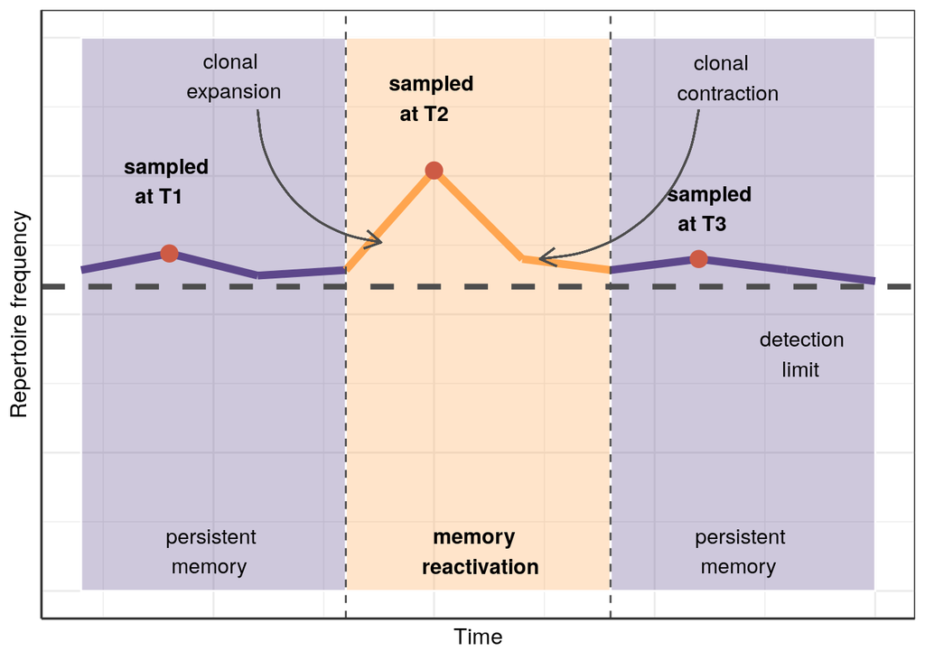

```r
p_scheme3 <- ggplot(df) +
  annotate("rect", ymin=0, ymax=0.01, xmin = 1, xmax = df$x1[4],
           alpha=0.3, fill = "mediumpurple4", color="white") +
  annotate("rect", ymin=0, ymax=0.01, xmin = df$x1[7], xmax = 10,
           alpha=0.3, fill = "mediumpurple4", color="white") +
  annotate("rect", ymin=0, ymax=0.01, xmin = df$x1[4], xmax = df$x1[7],
           alpha=0.3, fill = "tan1", color="white") +
  geom_line(aes(x = x1, y = y3, colour=(x1 > 3 & x1 < 7), group = 1),  size = 2) +
  geom_hline(yintercept = 0.0055, linetype="dashed", color = "grey30", size = 1.5) +
  geom_vline(xintercept = df$x1[4], linetype="dashed", color = "grey30") +
  geom_vline(xintercept = df$x1[7], linetype="dashed", color = "grey30") +
  annotate("text", x = 9.2, y=0.004, label = 'plain("detection \n    limit")', parse = TRUE, size = 4) +
  annotate("point", x = df$x1[2], y = df$y3[2], colour = "coral3", size = 4) +
  annotate("point", x = df$x1[5], y = df$y3[5], colour = "coral3", size = 4) +
  annotate("point", x = df$x1[8], y = df$y3[8], colour = "coral3", size = 4) +
  annotate("text", x = df$x1[2], y = df$y3[2] + 0.001, label = 'bold("sampled \n  at T1")', parse = TRUE, size = 4) +
  annotate("text", x = df$x1[5], y = df$y3[5] + 0.001, label = 'bold("sampled \n  at T2")', parse = TRUE, size =4) +
  annotate("text", x = df$x1[8] + 0.15, y = df$y3[8] + 0.0006, label = 'bold("sampled \n  at T3")', parse = TRUE, size = 4) +
  annotate("text", x = 2.5, y = 0.0004, label = 'plain("persistent \n memory")', parse = TRUE, size = 4) +
  annotate("text", x = 5.5, y = 0.0004, label = 'bold("   memory \n reactivation")', parse = TRUE, size = 4) +
  annotate("text", x = 8.5, y = 0.0004, label = 'plain("persistent \n memory")', parse = TRUE, size = 4) +
  annotate("text", x = 2.7, y = 0.009, label = 'plain("    clonal \n expansion")', parse = TRUE, size = 4) +
  annotate("text", x = 8.3, y = 0.009, label = 'plain("    clonal \n contraction")', parse = TRUE, size = 4) +
  geom_curve(x = 3, y = 0.0087, xend = 4.4, yend = 0.0063, curvature = 0.4, color = "grey30",
             arrow = arrow(length = unit(0.03, "npc"))) +
  geom_curve(x = 8, y = 0.0087, xend = 6.2, yend = 0.006, curvature = -0.4, color = "grey30",
             arrow = arrow(length = unit(0.03, "npc"))) +
  scale_colour_manual(values = c("mediumpurple4", "tan1")) +
  scale_y_continuous("Repertoire frequency", limits = c(0, 0.01)) +
  scale_x_continuous("Time") +
  #ggtitle("    Sampling of LBmem group") +
  my_theme +
  theme(axis.ticks.x=element_blank(),
        axis.ticks.y=element_blank(),
        axis.text.x=element_blank(),
        axis.text.y=element_blank())

p_scheme3
```

# Part 3. Reactivation of LBmem clonal groups is driven by positive selection.

### (Results from Figure 5B)

Loading genetic code and calculating per codon number of nonsynonymous and synonymous sites.

```r
gc <- geneticCodeTable(DNA = TRUE)
nucl <- c("A", "T", "G", "C")
Ss <- c()
Ns <- c()
for (i in 1:64) {
  codon <- unlist(str_split(gc$GeneticCode[i], ""))
  aa <- gc$AminoAcids[i]
  s = 0
  ### x - through 1, 2, 3 nucl of codon
  for (x in 1:3){
    subst <- nucl[nucl != codon[x]]
    ### for nucleotides, in which x can be substituted
    for (y in 1:3){
      subst_codon <- codon
      subst_codon[x] <- subst[y]
      subst_aa <- gc$AminoAcids[gc$GeneticCode == paste0(subst_codon, collapse = "")]
      if (aa == subst_aa) {s <- s + 1/3}
    }
  }
  Ss <- c(Ss, s)
  Ns <- c(Ns, 3-s)
}
gc$Ss <- Ss
gc$Ns <- Ns
```

#### Fig. 5B: McDonald-Kreitman estimate of the fraction of adaptive non-synonymous changes $\alpha$ between germline and MRCA in HBmem and LBmem clonal groups, wich have a nonzero G-MRCA distance. Comparisons were performed by Mann-Whitney test, notation of the level of significance is the following: * - $p\leq0.05$, ** - $p\leq0.01$, *** - $p\leq10^{-3}$, **** - $p\leq10^{-4}$.

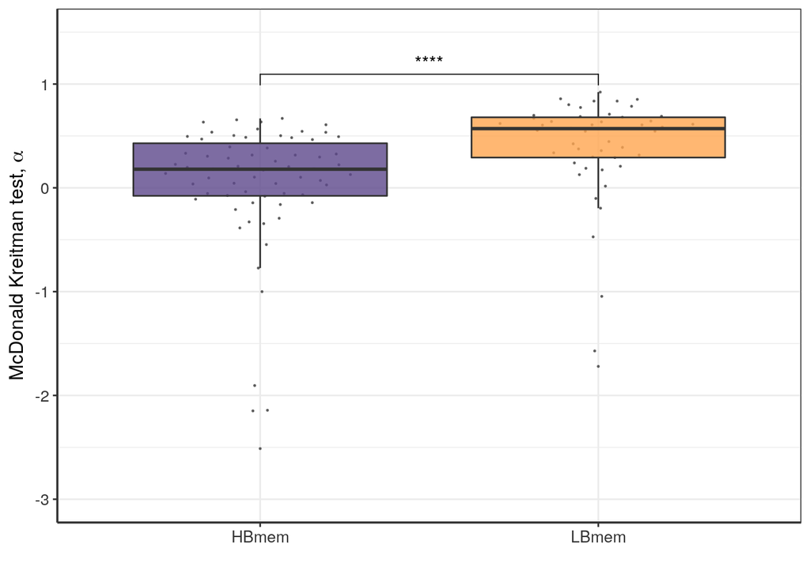

```r
thresholds_nice <- c("all", "no singletons", ">5%", ">10%", ">15%", ">20%", ">25%", ">30%")
mcd_kr <- c()

for (lin in lineage_composition$file){
  all <- read.FASTA(paste0(path, "alignments/", lin), type = "DNA")
  al_matrix <- as.character(as.matrix(all))
  al_matrix <- al_matrix[order(row.names(al_matrix)),]

  ## length of the sequence in the alignment
  l_seq <- length(all[[1]])
  l_full <- 3*(l_seq%/%3)
  ## number of conotypes
  n <- nrow(al_matrix)-2
  ## positions in codon
  index <- c(1,2,3)
  mutation_table <- c()

  for (pos in 1:(3*(l_seq%/%3))){

    n_codon <- (2 + pos)%/%3
    codon_pos <-  pos%%3
    if (codon_pos == 0){codon_pos = 3}
    ancestor_codon <- paste0(al_matrix['ancestor', (3*n_codon-2):(3*n_codon)], collapse = "")
    ancestor_nucl <- al_matrix['ancestor', pos]
    germline_codon <- paste0(al_matrix['germline', (3*n_codon-2):(3*n_codon)], collapse = "")
    germline_nucl <- al_matrix['germline', pos]

    variants_nucl <- unique(al_matrix[1:n, pos])
    ## remove - from variants here, so there is no such condition in if
    variants_nucl <- variants_nucl[variants_nucl != "-" & variants_nucl != al_matrix['ancestor', pos]]

    if (length(unique(c(ancestor_nucl, germline_nucl, variants_nucl))) > 1 &
      !str_detect(ancestor_codon, "-") & !str_detect(germline_codon, "-")) {
      # comparing germline with mrca
      if (germline_nucl == ancestor_nucl) {germ_mut = "0"
      } else if (is.element(germline_nucl, variants_nucl)) {
        germ_mut <- "poly"
      } else {
        ancestor_codon_change <- ancestor_codon
        substring(ancestor_codon_change, codon_pos, codon_pos) <- germline_nucl
        if (gc$AA[gc$GeneticCode == toupper(ancestor_codon)] ==
            gc$AA[gc$GeneticCode == toupper(ancestor_codon_change)]) {germ_mut = "S"
        } else {germ_mut = "N"}
      }
      # comparing variants with mrca
      if (length(variants_nucl) == 0) {
        var_mut = "0"
        var_freqs = "-"
      } else {
        var_mut = ""
        var_freqs = ""
        for (var in variants_nucl) {
          var_codon <- ancestor_codon
          substring(var_codon, codon_pos, codon_pos) <- var
          if (gc$AA[gc$GeneticCode == toupper(ancestor_codon)] ==
              gc$AA[gc$GeneticCode == toupper(var_codon)]) {
            var_mut <- str_glue(var_mut, "S")
            var_freqs <- str_glue(var_freqs, sum(al_matrix[1:n, pos] == var), "_")
          } else {
            var_mut = str_glue(var_mut, "N")
            var_freqs <- str_glue(var_freqs, sum(al_matrix[1:n, pos] == var), "_")
          }
        }
      }
      mutation_table <- rbind(mutation_table,
                                   c(pos, germ_mut, var_mut, var_freqs))
    }
  }
  mutation_table <- data.frame(mutation_table)
  colnames(mutation_table) <- c("pos", "germ_mut", "var_mut", "var_freqs")
  ### counting fixed-polymorphic as polymorphic
  Ds <- sum(mutation_table$germ_mut == "S")
  Dn <- sum(mutation_table$germ_mut == "N")

  mutation_table <-  mutation_table[mutation_table$var_mut != "0",]
  zz <- nrow(mutation_table)
  for (i in 1:zz){
    if (nchar(mutation_table$var_mut[i]) == 1){
      mutation_table$var_freqs[i] <- str_extract(mutation_table$var_freqs[i], "[0-9]*")
    } else {
      types <- unlist(str_split(mutation_table$var_mut[i], ""))
      freqs <- as.numeric(unlist(str_split(mutation_table$var_freqs[i], "_")))
      freqs <- freqs[!is.na(freqs)]
      ### counting each allele individually
      for (q in 1:length(types)){
        if (q == 1){
          mutation_table$var_mut[i] <- types[1]
          mutation_table$var_freqs[i] <- freqs[1]
        } else{
          mutation_table <- rbind(mutation_table,
                                c(mutation_table$pos[i], "-", types[q], freqs[q]))
        }
      }
    }
  }
  mutation_table$var_freqs <- round(as.numeric(mutation_table$var_freqs)/n, 5)
  thresholds <- c(0, round(1/n, 5), 0.05, 0.1, 0.15, 0.2, 0.25, 0.3)
  for (thr in thresholds) {
    Pn <- sum(mutation_table$var_mut[mutation_table$var_freqs > thr] == "N")
    Ps <- sum(mutation_table$var_mut[mutation_table$var_freqs > thr] == "S")

    alpha <- 1 - (((Pn+1)/(Ps+1)) / ((Dn+1)/(Ds+1)))
    cont_table <- matrix(c(Ds+1, Dn+1, Ps+1, Pn+1), nrow = 2,
    dimnames = list(c("Syn", "Nonsyn"), c("Fixed", "Poly")))
    f_test_gr <- fisher.test(cont_table, alternative = "greater")$p.value
    f_test_less <- fisher.test(cont_table, alternative = "less")$p.value
    f_test_two <- fisher.test(cont_table, alternative = "two.sided")$p.value

    mcd_kr <- rbind(mcd_kr,
                    c(lin, lineage_composition$cluster[lineage_composition$file == lin], alpha,
                      thresholds_nice[which(thresholds == thr)][1], f_test_gr, f_test_less,
                      f_test_two, Ds, Dn, Ps, Pn))
  }
}
mcd_kr <- data.frame(mcd_kr)
colnames(mcd_kr) <- c("clone", "cluster", "alpha", "thr", "p.val_gr", "p.val_less", "p.val_two", "Ds", "Dn", "Ps", "Pn")
mcd_kr[, c(3,5:11)] <- sapply(mcd_kr[, c(3,5:11)], as.numeric)
mcd_kr$thr <- factor(mcd_kr$thr, levels = thresholds_nice)

p_mcd <- ggplot(mcd_kr[mcd_kr$thr == "all" & (mcd_kr$Dn + mcd_kr$Ds) != 0,],
                aes(x = cluster, y = alpha, fill = cluster)) +
  geom_quasirandom(width=0.3, size = 0.2, color = "grey30", alpha = 0.8) +
  geom_boxplot(alpha = 0.8, outlier.colour = NA) +
  stat_compare_means(comparisons = cluster_comparisons, method = "wilcox.test", size = 4, paired = FALSE, label = "p.signif") +
  scale_y_continuous(name=TeX("McDonald Kreitman test, $\\alpha$"), limits = c(-3, 1.5)) +
  scale_x_discrete(name = "") +
  scale_fill_manual(values = c("HBmem" = "mediumpurple4", "LBmem" = "tan1"), name = "") +
  my_theme
p_mcd
```

#### Robustness of the comparison to the exclusion of low frequent SHMs:

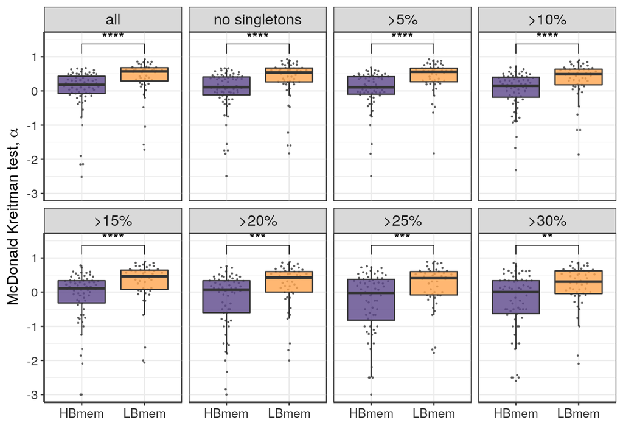

```r
p_mcd_thr <- ggplot(mcd_kr[(mcd_kr$Dn + mcd_kr$Ds) != 0,],
                aes(x = cluster, y = alpha, fill = cluster)) +
  geom_quasirandom(width=0.3, size = 0.2, color = "grey30", alpha = 0.8) +
  geom_boxplot(alpha = 0.8, outlier.colour = NA) +
  stat_compare_means(comparisons = cluster_comparisons, method = "wilcox.test", size = 4, paired = FALSE, label = "p.signif") +
  scale_y_continuous(name=TeX("McDonald Kreitman test, $\\alpha$"), limits = c(-3, 1.5)) +
  scale_x_discrete(name = "") +
  scale_fill_manual(values = c("HBmem" = "mediumpurple4", "LBmem" = "tan1"), name = "") +
  my_theme +
  facet_wrap(~thr, ncol = 4)
p_mcd_thr
```

#### Exact Fisher Test on joined variotion in HBmem cluster:

```r
H_cont_table <- matrix(apply(mcd_kr[mcd_kr$thr == "all" & mcd_kr$cluster == "HBmem", 8:11], 2, sum),
                       nrow = 2, dimnames = list(c("Syn", "Nonsyn"), c("Fixed", "Poly")))
fisher.test(H_cont_table, alternative = "less")
```

```
##
##  Fisher's Exact Test for Count Data
##
## data:  H_cont_table
## p-value = 1.246e-06
## alternative hypothesis: true odds ratio is less than 1
## 95 percent confidence interval:
##  0.0000000 0.5907553
## sample estimates:
## odds ratio
##  0.4259259
```

#### Exact Fisher Test on joined variotion in LBmem cluster:

```r
L_cont_table <- matrix(apply(mcd_kr[mcd_kr$thr == "all" & mcd_kr$cluster == "LBmem", 8:11], 2, sum),
                       nrow = 2, dimnames = list(c("Syn", "Nonsyn"), c("Fixed", "Poly")))
fisher.test(L_cont_table, alternative = "less")
```

```
##
##  Fisher's Exact Test for Count Data
##
## data:  L_cont_table
## p-value < 2.2e-16
## alternative hypothesis: true odds ratio is less than 1
## 95 percent confidence interval:
##  0.0000000 0.4367407
## sample estimates:
## odds ratio
##  0.3485001
```

# Part 4. Subsequent evolution of LBmem clonal groups is affected by negative and positive selection.

#### Fig. 5C: Comparison of mean pairwise $\pi N \pi S$ of HBmem and LBmem groups. Comparisons were performed by Mann-Whitney test, notation of the level of significance is the following: * - $p\leq0.05$, ** - $p\leq0.01$, *** - $p\leq10^{-3}$, **** - $p\leq10^{-4}$.

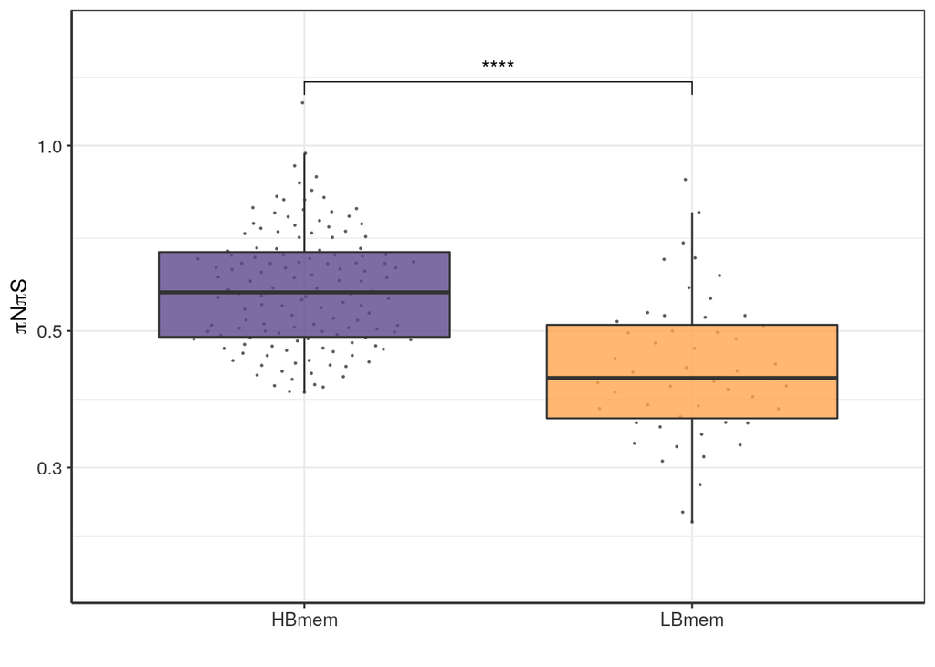

```r
pnps_table <- c()
sfs_all <- c()

bins <- seq(0.05, 1, by=0.05)
bins_0 <- seq(0, 0.95, by=0.05)
bin_l <- 0.05
Bins <- seq(0.2, 1.2, by = 0.2)
Bins_0 <- c(seq(0, 0.8, by = 0.2), 0)

for (lin in lineage_composition$file){
  al <- read.FASTA(paste0(path, "alignments/", lin), type = "DNA")
  al_matrix <- as.character(as.matrix(al))
  al_matrix <- al_matrix[order(row.names(al_matrix)),]

  clone_name <- substring(lin, 1, nchar(lin)-4)
  ## number of sequences in the lineage
  n <- nrow(al_matrix) -2
  ## exclude germline sequence from the alignment
  al_matrix <- al_matrix[1:(n+1),]
    ## length of the sequence in the alignment
  l_seq <- length(al[[1]])

  type_matrix <- c()
    mutation_table <- c()
  l_full <- 3*(l_seq%/%3)
  ## positions in codon
  index <- c(1,2,3)
  Ss_anc <- 0
  Ns_anc <- 0
  sites_table <- c()
  ###################pos
  for (pos in 1:(3*(l_seq%/%3))){

    n_codon <- (2 + pos)%/%3

    origin <- paste0(al_matrix[(n+1), (3*n_codon-2):(3*n_codon)], collapse = "")
    variants <- unique(al_matrix[,pos])
    variants <- variants[variants != "-" & variants != al_matrix[(n+1), pos]]

    if (!str_detect(origin, "-") & pos%%3 == 1){
      Ss_anc <- Ss_anc + gc$Ss[which(gc$GeneticCode == toupper(origin))]
      Ns_anc <- Ns_anc + gc$Ns[which(gc$GeneticCode == toupper(origin))]
    }

    if (length(variants) > 0 & !str_detect(origin, "-")) {

      for (var in variants) {
        pos_in_codon <- pos %% 3
        if (pos_in_codon == 0) {pos_in_codon = 3}
        var_codon <- unlist(str_split(origin, ""))
        var_codon[pos_in_codon] <- var
        var_codon <- paste0(var_codon, collapse = "")

        ## synonymous SNP
        if (gc$AA[which(gc$GeneticCode == toupper(paste(origin, collapse = '')))] ==
           gc$AA[which(gc$GeneticCode == toupper(paste(var_codon, collapse = '')))]){
           type <- "S"
           S_codon <- 1
           N_codon <- 0
        } else {
           type <- "N"
           S_codon <- 0
           N_codon <- 1
        }

        mutation_table <- rbind(mutation_table,
                                    c(n_codon, origin, var_codon, S_codon, N_codon,
                                      gc$Ss[gc$GeneticCode == toupper(origin)],
                                      gc$Ns[gc$GeneticCode == toupper(origin)],
                                      sum(al_matrix[1:n,pos] == var)/n, type))
      }
    }
  }
  ###################pos
  mutation_table <- data.frame(mutation_table)
  colnames(mutation_table) <- c("codon", "ancestor", "variant","S_l", "N_l", "Ss", "Ns",
                                "freq", "type")
  mutation_table[, c(1:9)] <- sapply(mutation_table[, c(1:9)], as.character)
  mutation_table[, c(1,4:9)] <- sapply(mutation_table[, c(1,4:9)], as.numeric)

  ## counting pnps
  for (b in Bins) {
    mt <- mutation_table[mutation_table$freq <= b & mutation_table$freq > Bins_0[which(b==Bins)],]
    N_mut <- sum(mt$N_l)
    S_mut <- sum(mt$S_l)
    pnps <- ((N_mut+1)/Ns_anc) / ((S_mut+1)/Ss_anc)

    mutN_all <- sum(mutation_table$N_l)
    mutS_all <- sum(mutation_table$S_l)

    pnps_norm <- ( ((N_mut+1)/(5+mutN_all)) / Ns_anc) /
                 ( ((S_mut+1)/(5+mutS_all)) / Ss_anc)

    pnps_table <- rbind(pnps_table, c(lin, b, pnps, "all",
                                      lineage_composition$cluster[lineage_composition$file == lin]))
    pnps_table <- rbind(pnps_table, c(lin, b, pnps_norm, "norm_all",
                                       lineage_composition$cluster[lineage_composition$file == lin]))
  }

  ## weighted spectrum
  sfs_scaled <- c()
  for (b in bins){
   sfs_scaled <- rbind(sfs_scaled,
                  c(b, nrow(mutation_table[mutation_table$freq <= b & mutation_table$freq > (b - bin_l) &
                                             mutation_table$type == "S",]),
                    nrow(mutation_table[mutation_table$freq <= b & mutation_table$freq > (b - bin_l) &
                                          mutation_table$type == "N",]),
                    nrow(mutation_table[mutation_table$freq <= b & mutation_table$freq > (b - bin_l),])))
  }
  sfs_scaled[,2] <- sfs_scaled[,2]/sum(sfs_scaled[,2])
  sfs_scaled[,3] <- sfs_scaled[,3]/sum(sfs_scaled[,3])
  sfs_scaled[,4] <- sfs_scaled[,4]/sum(sfs_scaled[,4])
  sfs_all <- rbind(sfs_all, cbind(sfs_scaled, rep(lin, 20), rep(n, 20),
                                  rep(lineage_composition$cluster[lineage_composition$file == lin], 20)))


}

pnps_table <- data.frame(pnps_table)
colnames(pnps_table) <- c("clone", "scale", "pnps", "calculation", "cluster")
pnps_table[, c(1:4)] <- sapply(pnps_table[, c(1:4)], as.character)
pnps_table[, c(3)] <- sapply(pnps_table[, c(3)], as.numeric)

sfs_all <- data.frame(sfs_all)
colnames(sfs_all) <- c("scale", "syn", "nonsyn", "all", "lineage_id", "size", "cluster")
sfs_all[, c(1:7)] <- sapply(sfs_all[, c(1:7)], as.character)
sfs_all[, c(1:4,6)] <- sapply(sfs_all[, c(1:4,6)], as.numeric)

p_pnps_all <- ggplot(pnps_table[(pnps_table$scale == "1.2" & pnps_table$calculation == "all"),],
                     aes(x = cluster, y = pnps, fill = cluster)) +
  geom_quasirandom(width=0.3, size = 0.2, color = "grey30", alpha = 0.8) +
  geom_boxplot(alpha = 0.8, outlier.colour = NA) +
  stat_compare_means(comparisons = cluster_comparisons, method = "wilcox.test", size = 4, paired = FALSE, label = "p.signif") +
  scale_y_log10(name=TeX("$\\pi$N$\\pi$S"), limits = c(0.2, 1.5)) +
  scale_x_discrete(name = "") +
  scale_fill_manual(values = c("HBmem" = "mediumpurple4", "LBmem" = "tan1"), name = "") +
  my_theme
p_pnps_all
```

#### Fig. 5D: Averaged site frequency spectrum for HBmem and LBmem clonal groups;

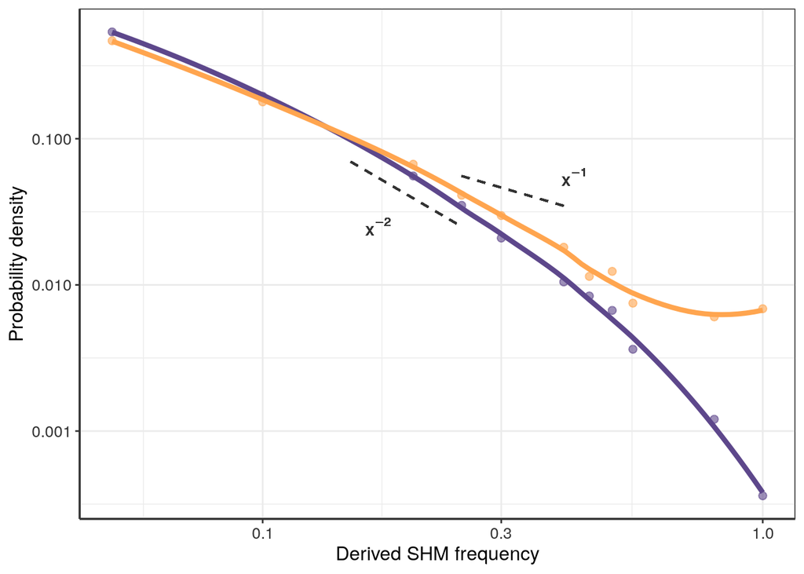

```r
#bins <- seq(0.05, 1, by=0.05)

sfs_all_plot <- c()
#groups_dop <- c("1", "2")
for (bin in bins){
  for (cluster in c("HBmem", "LBmem")){
    sfs_all_plot <- rbind(sfs_all_plot,
                c(bin, mean(sfs_all$all[sfs_all$scale == bin & sfs_all$cluster == cluster]),
      sd(sfs_all$all[sfs_all$scale == bin & sfs_all$cluster == cluster]), cluster))

  }
}
sfs_all_plot <- data.frame(sfs_all_plot)
colnames(sfs_all_plot) <- c("bin", "s", "sd", "cluster")

#sfs_all_plot$site <- factor(sfs_all_plot$site, labels = c("Nonsyn. sites", "Syn. sites"))
sfs_all_plot[, c(1:4)] <- sapply(sfs_all_plot[, c(1:4)], as.character)
sfs_all_plot[, c(1:3)] <- sapply(sfs_all_plot[, c(1:3)], as.numeric)

k <- 1/bins/sum(1/bins)
k2 <- 1/bins^2/sum(1/bins^2)

p_sfs_all <- ggplot(sfs_all_plot, aes(x = bin, y = s, color = cluster)) +
  geom_point(size = 2, alpha = 0.6) + geom_smooth(se = FALSE, size = 1.5, alpha = 0.4) +
 geom_segment(aes(x = bins[5], y = k[5], xend = bins[8], yend = k[8]),
              linetype="dashed", size=0.6, color = "grey20") +
  geom_text(aes(x=bins[8] + 0.02, y=k[8] + 0.02,  label = "x^{-1}"), parse=TRUE, color = "grey20") +
  geom_segment(aes(x = bins[3], y = k2[3], xend = bins[5], yend = k2[5]),
              linetype="dashed", size=0.6, color = "grey20") +
   geom_text(aes(x=bins[3] + 0.02, y=k2[5] ,  label = "x^{-2}"), parse=TRUE, color = "grey20") +
  scale_x_continuous(trans = 'log10', name=("Derived SHM frequency")) +
   scale_y_continuous(trans = 'log10', name=("Probability density")) +
  my_colors +
  #facet_wrap(~site, nrow = 2) +
  my_theme
p_sfs_all
```

#### Fig. 5E: Comparison of normalised $\pi N \pi S$ HBmem and LBmem clonal groups in bins of SHM frequencies. The number of polymorphisms in each bin is normalised by the overall number of polymorphisms in a corresponding clonal group; Comparisons were performed by Mann-Whitney test with Bonferroni-Holm multiple testing correction, notation of the level of significance is the following: * - $p\leq0.05$, ** - $p\leq0.01$, *** - $p\leq10^{-3}$, **** - $p\leq10^{-4}$.

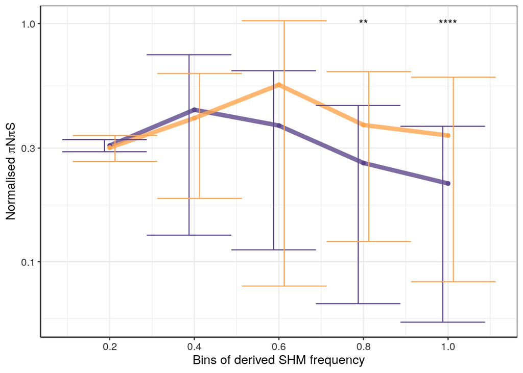

```r
data_summary <- function(data, varname, groupnames){
  require(plyr)
  summary_func <- function(x, col){
    c(mean = mean(x[[col]], na.rm=TRUE),
      sd = sd(x[[col]], na.rm=TRUE))
  }
  data_sum<-ddply(data, groupnames, .fun=summary_func,
                  varname)
  data_sum <- rename(data_sum, c("mean" = varname))
 return(data_sum)
}

df_pnps <- data_summary(pnps_table[(pnps_table$calculation == "norm_all") & pnps_table$scale != "1.2",],
                        varname="pnps", groupnames=c("scale", "calculation", "cluster"))

p_pnps_sfs <- ggplot(df_pnps, aes(x=as.numeric(scale), y=pnps, group=cluster, color=cluster)) +
  geom_line(size = 2, alpha = 0.8) +
  geom_point()+
  geom_errorbar(aes(ymin=pnps-sd, ymax=pnps+sd), width=.4,
                 position=position_dodge(0.05)) +
  annotate("text", x = 0.8, y = 1, label= "**", size = 4) +
  annotate("text", x = 1, y = 1, label = "****", size = 4) +
  scale_y_log10(name=TeX("Normalised $\\pi$N$\\pi$S")) +
  scale_x_continuous(name=("Bins of derived SHM frequency"), breaks = Bins[1:5]) +
  my_colors +
  my_theme
p_pnps_sfs
```

#### Mann-Whitney test with Bonferroni-Holm multiple testing correction for comparison of normalised $\pi N \pi S$ in bins of SHM frequency.

```r
bins <- seq(0.2, 1, 0.2)
for (bin in bins){
   print(paste0("Frequency bin = ", bin))
  x <- wilcox.test(pnps_table$pnps[pnps_table$scale == as.character(bin) & pnps_table$calculation == "norm_all"
                              & pnps_table$cluster == "HBmem"],
              pnps_table$pnps[pnps_table$scale == as.character(bin) & pnps_table$calculation == "norm_all"
                              & pnps_table$cluster == "LBmem"])
   print(paste0("Correction: p-value = ", x$p.value*5))
}
```

```
## [1] "Frequency bin = 0.2"
## [1] "Correction: p-value = 1.02946983741001"
## [1] "Frequency bin = 0.4"
## [1] "Correction: p-value = 2.52310797573261"
## [1] "Frequency bin = 0.6"
## [1] "Correction: p-value = 0.106248978778457"
## [1] "Frequency bin = 0.8"
## [1] "Correction: p-value = 0.00126748749887559"
## [1] "Frequency bin = 1"
## [1] "Correction: p-value = 2.11615053307368e-05"
```